# El repertorio normativo del debate previsional

Sección 5.2: conceptos y posturas en los tres debates previsionales

Este reporte respalda la sección 5.2 del manuscrito. Describe qué conceptos del libro de códigos aparecen en los debates de la PGU (leyes 21.419 y 21.538) y del sistema mixto (Ley 21.735), con qué postura y cuáles concentran la disputa. Usa las anotaciones de GPT-6 Luna, el modelo principal.

La unidad de los porcentajes es la **intervención sustantiva**. Una intervención cuenta una vez por concepto y postura aunque lo exprese en varios fragmentos (sección 4.1 del material suplementario). Una intervención puede apoyar y rechazar el mismo concepto en pasajes distintos.

## Seteo de la sesión

Cargamos los paquetes, la base analítica compartida por los reportes de resultados y el helper de tablas APA 7. `R/analysis_base.R` lee el censo, une los metadatos de actores por `unit_id`, marca las intervenciones sustantivas y excluye identidad y control individual según la regla de inclusión de la sección 5.1.

**Código**

```r
pacman::p_load(arrow, dplyr, tidyr, purrr, stringr, forcats, readr,
               jsonlite, ggplot2, scales, flextable, officer)
source("R/analysis_base.R")
source("R/apa7_word_table.R")

TABLE_DIR <- "output/tables/resultados"
FIGURE_DIR <- "output/figures/resultados"
dir.create(TABLE_DIR, recursive = TRUE, showWarnings = FALSE)
dir.create(FIGURE_DIR, recursive = TRUE, showWarnings = FALSE)

# Par divergente validado (apoyo / rechazo) con el validador de paletas.
STANCE_COLORS <- c(Apoyo = "#2a78d6", Rechazo = "#e34948")
theme_set(theme_minimal(base_size = 11) +
            theme(panel.grid.minor = element_blank(),
                  panel.grid.major.y = element_blank()))
```

## Base analítica

La base reúne una fila por intervención y una fila por declaración, es decir, por combinación intervención sustantiva × concepto × postura. Las posturas incorporan la adjudicación humana de los desacuerdos entre censos (`docs/decisiones-validacion.md`, sección 5). Una intervención es sustantiva si tiene al menos un fragmento con declaraciones o que el modelo no marcó como votación o procedimiento: un fragmento que justifica un voto con razones normativas se conserva. Los totales de intervenciones deben coincidir con la Tabla 1 del manuscrito.

**Código**

```r
base <- load_analysis_base(LUNA_RUN_DIR)
# Las leyes 21.419 y 21.538 se agrupan como debates de la PGU, como en H3.
interventions <- base$interventions |>
  mutate(debate = factor(if_else(debate == "PGU", "PGU", "Sistema mixto"),
                         levels = c("PGU", "Sistema mixto")))
claims <- base$claims |>
  left_join(interventions |>
              select(law_number, document_uri, utterance_id, law, debate,
                     phase, speaker_id),
            by = c("law_number", "document_uri", "utterance_id"))
concepts <- read_codebook_concepts() |> filter(analyzed)

stopifnot(
  identical(as.integer(table(interventions$law)), c(262L, 111L, 723L)),
  !anyNA(claims$law), !anyNA(claims$speaker_id),
  setequal(unique(claims$concept_id), concepts$concept_id)
)
# Decisiones de adjudicación aplicadas a las posturas de Luna.
base$adjudication |>
  count(decision) |>
  knitr::kable(col.names = c("Decisión", "Bloques × concepto"))
```

| Decisión | Bloques × concepto |
| --- | --- |
| both | 11 |
| concept_absent | 6 |
| oppose | 19 |
| support | 24 |

Se aplican 60 decisiones de adjudicación, que reemplazan la postura de Luna en otros tantos bloques × concepto; cuando el concepto no corresponde, la anotación se elimina. Son menos del 3 % de las anotaciones del censo, concentradas en conciencia de costos, previsión como mercado e ineficiencia y riesgo estatal.

## Denominadores

Para cada ley, y para cada fase de la reforma, contamos las intervenciones totales, las descartadas por estar compuestas solo de votaciones o procedimiento, las sustantivas y las que contienen al menos una declaración. Los actores con perfil son quienes formularon al menos una declaración. En la fila total, los actores se cuentan una vez aunque intervengan en varias leyes.

**Código**

```r
summarise_window <- function(intv, clm) {
  tibble(
    intervenciones = nrow(intv),
    descartadas = sum(!intv$substantive),
    sustantivas = sum(intv$substantive),
    con_declaraciones = n_distinct(clm$document_uri, clm$utterance_id),
    actores_perfil = n_distinct(clm$speaker_id),
    declaraciones = nrow(clm)
  )
}
by_law <- map(levels(interventions$law), \(l) {
  summarise_window(filter(interventions, law == l), filter(claims, law == l)) |>
    mutate(ventana = l, .before = 1)
})
by_phase <- map(levels(interventions$phase), \(p) {
  summarise_window(filter(interventions, phase == p),
                   filter(claims, phase == p)) |>
    mutate(ventana = paste0("   ", p), .before = 1)
})
denominators <- bind_rows(by_law[1:2], by_law[3], by_phase,
                          summarise_window(interventions, claims) |>
                            mutate(ventana = "Total", .before = 1))
stopifnot(sum(denominators$intervenciones[1:3]) == 1096L,
          sum(denominators$sustantivas[4:6]) == denominators$sustantivas[3])

# Los porcentajes acompañan a su recuento en la misma celda: descartadas sobre
# el total de intervenciones; con declaraciones sobre las sustantivas.
n_pct <- function(n, total) {
  sprintf("%s (%s %%)", format(n, big.mark = ".", decimal.mark = ","), round(100 * n / total))
}
denominators_display <- denominators |>
  transmute(`Ley y fase` = ventana,
            Intervenciones = format(intervenciones, big.mark = ".", decimal.mark = ","),
            `Descartadas (%)` = n_pct(descartadas, intervenciones),
            Sustantivas = format(sustantivas, big.mark = ".", decimal.mark = ","),
            `Con declaraciones (%)` = n_pct(con_declaraciones, sustantivas),
            `Actores con perfil` = format(actores_perfil, big.mark = ".", decimal.mark = ","),
            Declaraciones = format(declaraciones, big.mark = ".", decimal.mark = ","))
knitr::kable(denominators_display, align = c("l", rep("r", 6)))
```

Tabla 1: Intervenciones, actores con perfil y declaraciones por ley y fase legislativa

| Ley y fase | Intervenciones | Descartadas (%) | Sustantivas | Con declaraciones (%) | Actores con perfil | Declaraciones |
| --- | --- | --- | --- | --- | --- | --- |
| Ley 21.419 | 262 | 139 (53 %) | 123 | 108 (88 %) | 76 | 277 |
| Ley 21.538 | 111 | 52 (47 %) | 59 | 48 (81 %) | 42 | 97 |
| Ley 21.735 | 723 | 365 (50 %) | 358 | 330 (92 %) | 186 | 1.345 |
| Cámara 2024 | 320 | 183 (57 %) | 137 | 121 (88 %) | 104 | 445 |
| Senado 2025 | 209 | 137 (66 %) | 72 | 64 (89 %) | 44 | 309 |
| Cámara 2025 | 194 | 45 (23 %) | 149 | 145 (97 %) | 131 | 591 |
| Total | 1.096 | 556 (51 %) | 540 | 486 (90 %) | 219 | 1.719 |

De las 1.096 intervenciones, 556 (51%) se descartan por estar compuestas solo de votaciones o procedimiento. En su mayoría son intervenciones de la mesa (presidencia, vicepresidencia y secretaría: 428 de 556) y son breves (mediana de 30.5 palabras, frente a 443.5 en las sustantivas). Por ello, el corpus analítico se reduce a 540 intervenciones sustantivas. De ellas, 90% contiene al menos una declaración: casi toda intervención sustantiva justifica su posición con algún concepto del libro. La proporción es mayor en la Cámara 2025 (97%) que en la Cámara 2024 (88%).

El diseño es asimétrico: la reforma reúne 186 actores con perfil y 1.345 declaraciones, frente a 76 y 42 actores en las leyes de la PGU. Las proporciones de la Ley 21.538 descansan en 59 intervenciones y deben leerse con cautela. Las fases de la reforma también difieren: el Senado aporta solo 44 actores con perfil.

## Apoyo y rechazo por concepto y debate

Para cada debate (PGU, que agrupa las leyes 21.419 y 21.538, y sistema mixto) calculamos la proporción de intervenciones sustantivas que apoyan cada concepto y la proporción que lo rechaza ($f_{cts}$ en el material suplementario). El denominador incluye las intervenciones sustantivas sin declaraciones, de modo que las proporciones son comparables entre conceptos y debates aunque estos difieran en tamaño.

**Código**

```r
debate_sizes <- interventions |>
  filter(substantive) |>
  count(debate, name = "sustantivas")
prevalence <- claims |>
  count(debate, concept_id, stance) |>
  complete(debate, concept_id = concepts$concept_id,
           stance = c("support", "oppose"), fill = list(n = 0L)) |>
  left_join(debate_sizes, by = "debate") |>
  mutate(proporcion = n / sustantivas) |>
  left_join(concepts, by = "concept_id")
stopifnot(all(prevalence$proporcion <= 1))
write_parquet(prevalence, file.path(TABLE_DIR, "prevalencia_postura_debate.parquet"))

# Para citar proporciones en el texto.
pct <- function(d, c, s = "support") {
  percent(prevalence$proporcion[prevalence$debate == d & prevalence$concept_id == c &
                                  prevalence$stance == s], accuracy = 1)
}
```

La figura ordena los conceptos por familia del libro de códigos y, dentro de cada familia, por su presencia en el sistema mixto. El apoyo se dibuja a la derecha del cero y el rechazo a la izquierda; la posición y el color codifican la postura. Cada barra de al menos 3 % lleva su porcentaje. Los espacios entre grupos de conceptos corresponden a las familias del libro, sin rotular. Actitud se omite de la figura porque prácticamente no se registra; su ausencia se comenta en la interpretación.

**Código**

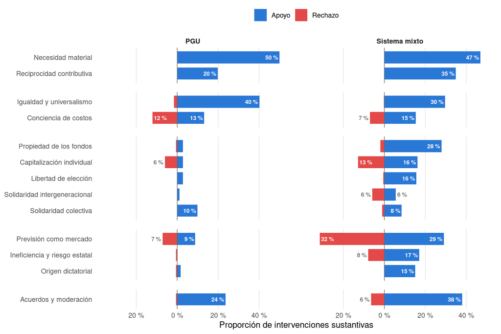

Figura 1: Proporción de intervenciones sustantivas que apoyan o rechazan cada concepto, por debate

```r
family_short <- c(
  "CARIN" = "CARIN", "Criterio contextual" = "Contextual",
  "Justificación distributiva del caso" = "Distributiva\ndel caso",
  "Justificación institucional del caso" = "Institucional\ndel caso",
  "Justificación procedimental del caso" = "Procedimental"
)
concept_order <- prevalence |>
  filter(debate == "Sistema mixto") |>
  group_by(concept) |>
  summarise(total = sum(proporcion)) |>
  arrange(total) |>
  pull(concept)
plot_data <- prevalence |>
  filter(concept_id != "actitud") |>
  mutate(valor = if_else(stance == "support", proporcion, -proporcion),
         postura = if_else(stance == "support", "Apoyo", "Rechazo"),
         concept = factor(concept, levels = concept_order),
         familia = factor(family_short[family], levels = family_short),
         etiqueta = paste0(round(100 * abs(valor)), " %"))

fig_prevalencia <- ggplot(plot_data, aes(x = valor, y = concept, fill = postura)) +
  geom_col(width = 0.75) +
  geom_vline(xintercept = 0, linewidth = 0.3, color = "grey40") +
  # Porcentaje en blanco dentro de la barra cuando cabe (8 % o más) y en gris
  # junto a ella entre 3 % y 8 %; las barras menores se leen como cercanas a cero.
  geom_text(data = \(d) filter(d, abs(valor) >= 0.08),
            aes(label = etiqueta, hjust = if_else(valor > 0, 1.1, -0.1)),
            color = "white", size = 2.6, fontface = "bold") +
  geom_text(data = \(d) filter(d, abs(valor) >= 0.03, abs(valor) < 0.08),
            aes(label = etiqueta, hjust = if_else(valor > 0, -0.15, 1.15)),
            color = "grey25", size = 2.6) +
  # Las familias del libro separan los grupos de conceptos sin rotularse.
  facet_grid(familia ~ debate, scales = "free_y", space = "free_y") +
  scale_x_continuous(labels = \(x) paste0(round(100 * abs(x)), " %"),
                     breaks = seq(-0.2, 0.4, 0.2),
                     expand = expansion(mult = c(0.1, 0.06))) +
  scale_fill_manual(values = STANCE_COLORS) +
  labs(x = "Proporción de intervenciones sustantivas", y = NULL, fill = NULL) +
  theme(legend.position = "top",
        strip.text.y = element_blank(),
        strip.text.x = element_text(face = "bold"),
        panel.spacing.x = unit(1.2, "lines"),
        panel.spacing.y = unit(0.8, "lines"))
print(fig_prevalencia)
ggsave(file.path(FIGURE_DIR, "figura4_prevalencia_postura.png"), fig_prevalencia,
       width = 9, height = 6, dpi = 300, bg = "white")
```

La necesidad material es el concepto con más apoyo en ambos debates (50% y 47% de las intervenciones sustantivas) y nunca recibe rechazo. La reciprocidad contributiva sigue el mismo patrón: apoyo en ambos debates, mayor en el sistema mixto (20% y 35%), y ningún rechazo. En los debates de la PGU destaca la igualdad y el universalismo (40%, frente a 30% en el sistema mixto).

El sistema mixto amplía el repertorio. Los conceptos distributivos e institucionales del caso, escasos en los debates de la PGU, alcanzan en el sistema mixto proporciones de apoyo de entre 6% (solidaridad intergeneracional) y 29% (previsión como mercado; 9% en la PGU). El rechazo de la previsión como mercado (32%) supera a su apoyo. Acuerdos y moderación aparece con apoyo en 38% de las intervenciones del sistema mixto (24% en la PGU).

Actitud registra 2 declaraciones en todo el corpus.

## Conceptos consensuales y disputados

La proporción minoritaria de un concepto es la parte de sus declaraciones con postura que está en la postura menos frecuente, $m_{cL} = \min(n^+, n^-)/(n^+ + n^-)$. Vale 0 cuando el concepto recibe una sola postura y 50 % cuando se divide por mitades. Se calcula por debate; con menos de 10 declaraciones la proporción se marca con † porque es inestable. Actitud se omite, como en la figura.

**Código**

```r
dispute <- prevalence |>
  select(debate, concept_id, concept, family, stance, n) |>
  pivot_wider(names_from = stance, values_from = n) |>
  mutate(total = support + oppose,
         minoritaria = if_else(total > 0, pmin(support, oppose) / total,
                               NA_real_))
write_parquet(dispute, file.path(TABLE_DIR, "disputa_concepto_debate.parquet"))

dispute_cells <- dispute |>
  filter(concept_id != "actitud") |>
  mutate(cell = case_when(
    total == 0 ~ "—",
    TRUE ~ sprintf("%d / %d (%s %%)%s", support, oppose,
                   round(100 * minoritaria), if_else(total < 10, "†", "")))) |>
  select(concept_id, concept, debate, cell) |>
  pivot_wider(names_from = debate, values_from = cell) |>
  left_join(dispute |>
              filter(debate == "Sistema mixto") |>
              select(concept_id, orden = minoritaria, n_reforma = total),
            by = "concept_id") |>
  arrange(desc(orden), desc(n_reforma)) |>
  select(-concept_id, -orden, -n_reforma) |>
  rename(Concepto = concept)
knitr::kable(dispute_cells, align = c("l", "c", "c"))
```

Tabla 2: Declaraciones de apoyo y rechazo y proporción minoritaria por concepto y debate

| Concepto | PGU | Sistema mixto |
| --- | --- | --- |
| Solidaridad intergeneracional | 2 / 0 (0 %)† | 20 / 21 (49 %) |
| Previsión como mercado | 16 / 13 (45 %) | 104 / 113 (48 %) |
| Capitalización individual | 5 / 11 (31 %) | 58 / 46 (44 %) |
| Ineficiencia y riesgo estatal | 0 / 1 (0 %)† | 61 / 28 (31 %) |
| Conciencia de costos | 24 / 22 (48 %) | 55 / 25 (31 %) |
| Acuerdos y moderación | 43 / 1 (2 %) | 136 / 23 (14 %) |
| Solidaridad colectiva | 18 / 0 (0 %) | 30 / 4 (12 %) |
| Propiedad de los fondos | 5 / 1 (17 %)† | 100 / 7 (7 %) |
| Libertad de elección | 5 / 0 (0 %)† | 56 / 2 (3 %) |
| Igualdad y universalismo | 73 / 3 (4 %) | 106 / 1 (1 %) |
| Necesidad material | 91 / 0 (0 %) | 168 / 0 (0 %) |
| Reciprocidad contributiva | 36 / 0 (0 %) | 125 / 0 (0 %) |
| Origen dictatorial | 3 / 1 (25 %)† | 54 / 0 (0 %) |

La tabla respalda el texto de la sección 5.2: los conceptos se ordenan por su proporción minoritaria en el sistema mixto.